# FALL2017 DA5030 Term Project

Xing Yang

2017/12/6

```r
library(ggplot2)
library(ggthemes)
library(parallel)
library(gridExtra)
library(tidyverse)
library(psych)
library(mice)
library(zipcode)
library(h2o)
library(caret)
library(ROCR)
library(h2oEnsemble)
```

# Data Acquisition

## Data Description

```r
#this data contain train and test
full <- read.csv("/Users/xingyang/Desktop/5030/Train.csv", stringsAsFactors = T)
str(full)
```

```
## 'data.frame':    7578 obs. of  18 variables:
##  $ id               : int  1 2 3 4 5 6 7 8 9 10 ...
##  $ tenure           : int  12 18 4 16 14 14 19 13 11 14 ...
##  $ claim.ind        : int  0 0 0 0 0 0 0 1 1 0 ...
##  $ n.adults         : int  4 2 2 1 3 3 1 1 1 4 ...
##  $ n.children       : int  2 0 0 0 3 0 1 0 3 1 ...
##  $ ni.gender        : Factor w/ 2 levels "F","M": 1 2 2 1 2 1 1 2 1 2 ...
##  $ ni.marital.status: int  1 1 0 1 1 0 0 0 1 1 ...
##  $ premium          : num  896 828 1003 1092 885 ...
##  $ sales.channel    : Factor w/ 3 levels "Broker","Online",..: 1 1 3 1 3 1 3 1 1 1 ...
##  $ coverage.type    : Factor w/ 3 levels "A","B","C": 2 3 2 3 1 3 1 3 3 3 ...
##  $ dwelling.type    : Factor w/ 3 levels "Condo","House",..: 1 3 2 1 3 2 3 1 3 2 ...
##  $ len.at.res       : num  13 15 10 22 18 19 21 10 18 16 ...
##  $ credit           : Factor w/ 3 levels "high","low","medium": 1 1 3 1 2 1 1 1 3 1 ...
##  $ house.color      : Factor w/ 4 levels "blue","red","white",..: 1 3 1 2 3 3 3 1 2 3 ...
##  $ ni.age           : num  47 47 30 38 49 40 51 47 42 50 ...
##  $ year             : int  2013 2013 2013 2013 2013 2013 2013 2013 2013 2013 ...
##  $ zip.code         : int  80020 50025 50025 80026 50054 85076 15057 85027 50020 50009 ...
##  $ cancel           : int  0 0 0 0 0 0 0 0 0 0 ...
```

ID: Policy ID tenure: Number of years with Kangaroo claim.ind: Occurrence of claim (0=no, 1=yes) n.adults: Number of adults in the property n.children: Number of children in the property ni.gender: Gender of policyholder ni.marital.status: Marital status of policyholder (0=no, 1=yes) premium: Price of the policy sales.channel: Medium through which policy was purchased coverage.type: Type of coverage dwelling.type: Type of dwelling len.at.res: Length at residence (how long policyholder lived at property) credit: Financial credit level of policyholder house.Color: Color of house ni.age: Age of policholder year: Year of the policy zip.code: Zip code of the property cancel: cancelation indicator (0=no, 1=yes). This is the response variable and “-1” is invalid value.

# Data exploration

## Exploratory data plots

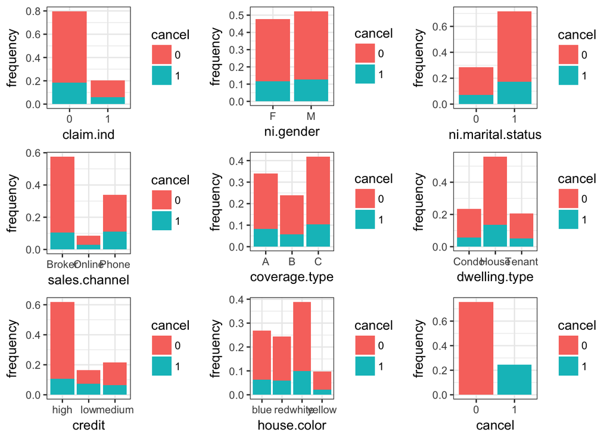

```r
#delet cancel is '-1' and ID
full1 <- full[-1]
full2 <- full1[!full1$cancel==-1,]
full2$ni.marital.status <- as.factor(full2$ni.marital.status)
full2$claim.ind <- as.factor(full2$claim.ind)
full2$cancel <- as.factor(full2$cancel)

#data visualization
#frequency funcion
plot_freq <- function(data, col_name) {
  data <- data.frame(x = data[, col_name], cancel = data$cancel)
  freq <- ggplot(data = subset(data, !is.na(x)), aes(x = x, fill = cancel)) +
    geom_bar(aes(y = (..count..)/sum(..count..))) +
    xlab(col_name) +
    ylab('frequency') +
    theme_bw()
  return(freq)
}
#histogram funcion
plot_hist <- function(data, col_name) {
  data <- data.frame(x = data[, col_name], cancel = data$cancel)
  hist <- ggplot(data = subset(data, !is.na(x)), aes(x = x,  fill = cancel)) +
    geom_histogram(binwidth = 1) +
    xlab(col_name) +
    theme_bw()
  return(hist)
}

#use grid.arragne to get combine grap
plots_muti <- function(data, fun, col_names_vector, ncol = 3) {
  plt_list <- mclapply(col_names_vector, mc.preschedule = TRUE, mc.cores = 8, function(col_name) {
    plt <- fun(data = data, col_name = col_name)
  })
  do.call("grid.arrange", c(plt_list, ncol = ncol))
}

factorname <- colnames(full2[,sapply(full2, is.factor)])
numericname <- colnames(full2[, sapply(full2, function(x) !is.factor(x))])
plots_muti(data = full2, fun = plot_freq, col_names_vector = factorname, ncol = 3)
```

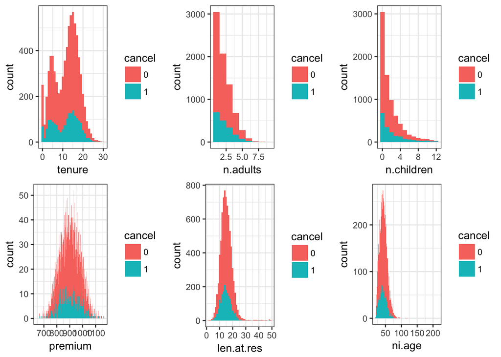

```r
#delete zipcode and year, I will convert zipcode to state, too.
plots_muti(data = full2, fun = plot_hist, col_names_vector = numericname[c(-7, -8)], ncol = 3)
```

## Detection of outliers

```r
summary(full2)
```

```
##      tenure      claim.ind      n.adults       n.children     ni.gender
##  Min.   : 0.00   0   :6011   Min.   :1.000   Min.   : 0.000   F   :3596
##  1st Qu.: 6.00   1   :1532   1st Qu.:1.000   1st Qu.: 0.000   M   :3945
##  Median :13.00   NA's:  10   Median :2.000   Median : 1.000   NA's:  12
##  Mean   :11.71               Mean   :2.134   Mean   : 1.779
##  3rd Qu.:16.00               3rd Qu.:3.000   3rd Qu.: 3.000
##  Max.   :30.00               Max.   :9.000   Max.   :12.000
##  NA's   :2                   NA's   :5       NA's   :1
##  ni.marital.status    premium       sales.channel coverage.type
##  0   :2139         Min.   : 645.8   Broker:4343   A   :2575
##  1   :5407         1st Qu.: 845.8   Online: 643   B   :1810
##  NA's:   7         Median : 901.5   Phone :2555   C   :3164
##                    Mean   : 901.4   NA's  :  12   NA's:   4
##                    3rd Qu.: 956.3
##                    Max.   :1164.8
##                    NA's   :6
##  dwelling.type   len.at.res       credit     house.color
##  Condo :1767   Min.   : 2.00   high  :4666   blue  :2028
##  House :4221   1st Qu.:12.00   low   :1240   red   :1846
##  Tenant:1554   Median :15.00   medium:1636   white :2932
##  NA's  :  11   Mean   :15.20   NA's  :  11   yellow: 739
##                3rd Qu.:18.00                 NA's  :   8
##                Max.   :49.41
##                NA's   :5
##      ni.age            year         zip.code     cancel
##  Min.   : 19.00   Min.   :2013   Min.   :15001   0:5710
##  1st Qu.: 35.00   1st Qu.:2014   1st Qu.:50013   1:1843
##  Median : 43.00   Median :2015   Median :80013
##  Mean   : 43.63   Mean   :2015   Mean   :62274
##  3rd Qu.: 51.00   3rd Qu.:2016   3rd Qu.:85034
##  Max.   :216.50   Max.   :2016   Max.   :98038
##  NA's   :7                       NA's   :4
```

Through comparing the median, mean, maximum and minimum and from above graphs, I think that outlier should exist in the n.adults, n.children, ni.age, and len.at.res.

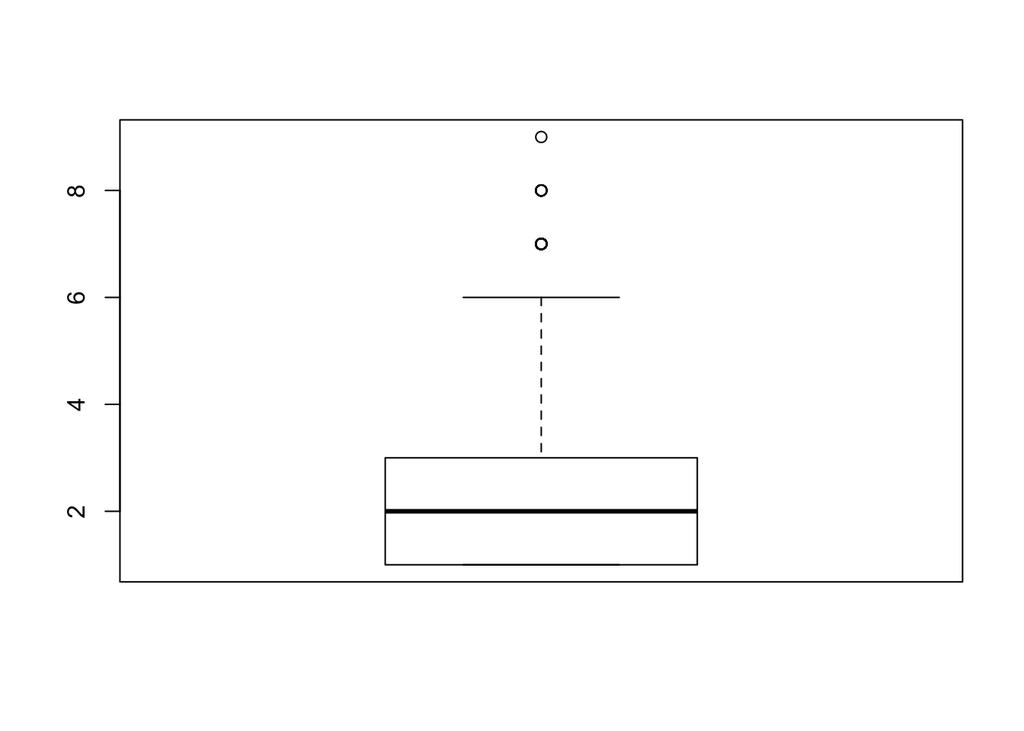

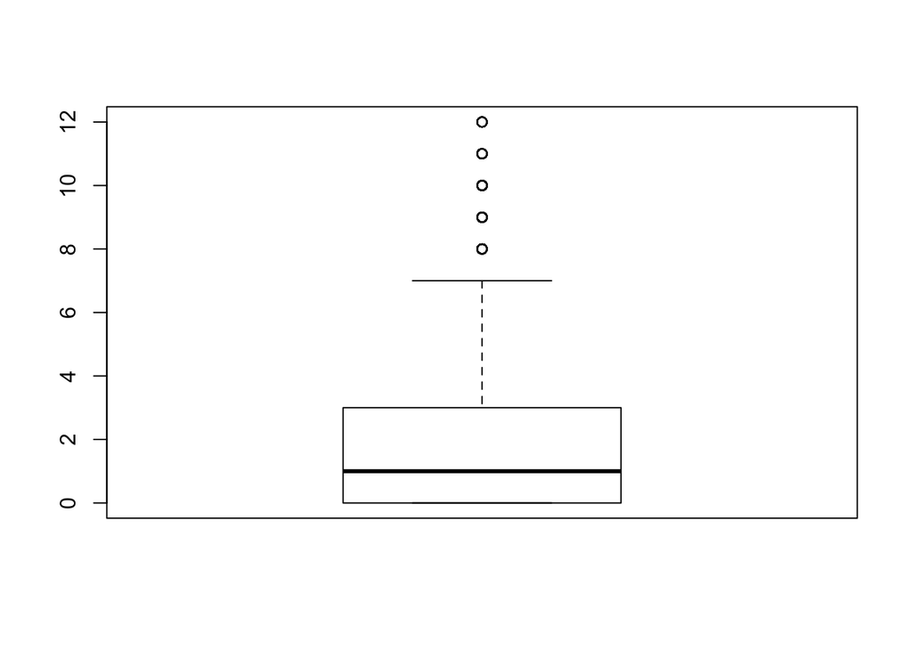

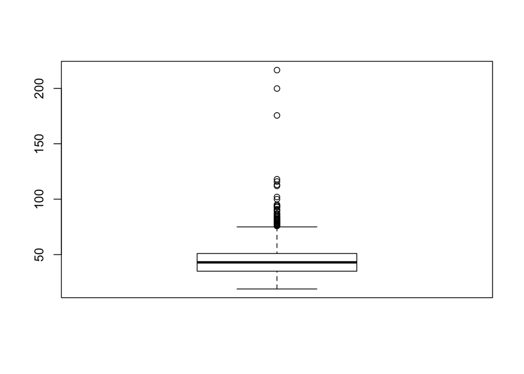

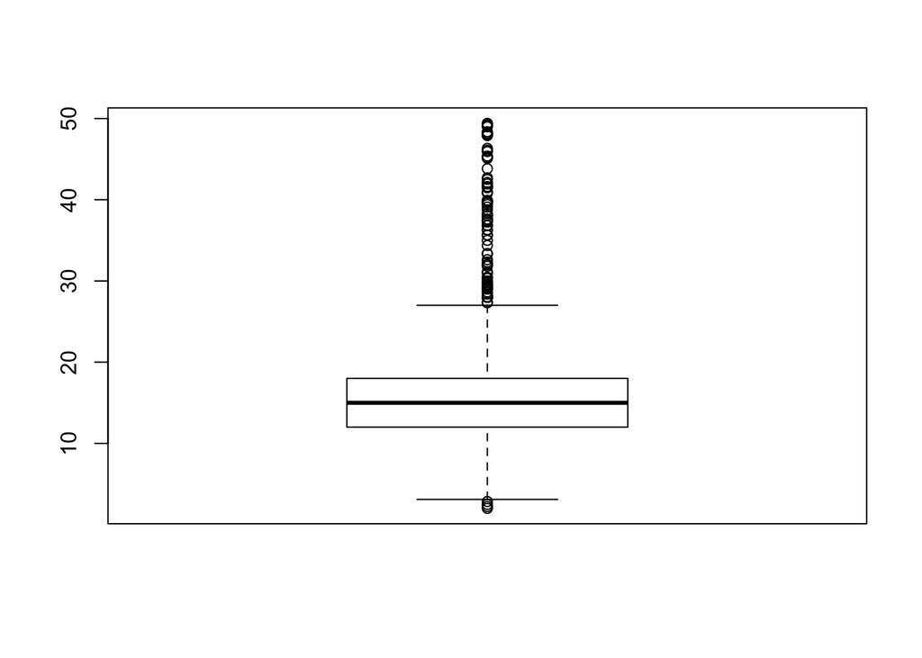

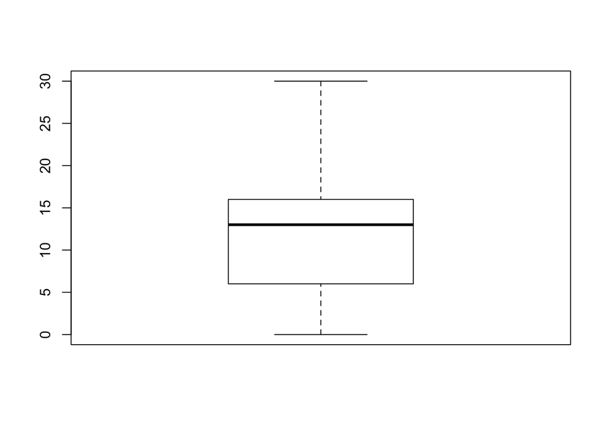

```
##       n.adults   n.children  ni.age     len.at.res tenure
## stats Numeric,5  Numeric,5   Numeric,5  Numeric,5  Numeric,5
## n     7548       7552        7546       7548       7551
## conf  Numeric,2  Numeric,2   Numeric,2  Numeric,2  Numeric,2
## out   Numeric,29 Numeric,312 Numeric,73 Numeric,87 Numeric,0
## group Numeric,29 Numeric,312 Numeric,73 Numeric,87 Numeric,0
## names "1"        "1"         "1"        "1"        "1"
```

```r
out <- select(full2, n.adults, n.children, ni.age, len.at.res, tenure)
sapply(out, boxplot)
```

From the boxplot, the tenure do not have outliers, the number of n.adult which is larger than 6 would be outlier and n.children is larger than 7. For the ni.age and len.at.res, these that are more than 3 standard deviations from the mean would be the outlier. I let these outliers be NA.

```r
full2$n.adults[full2$n.adults > 6] <- NA
full2$n.children[full2$n.children > 7] <- NA

ni.ageupper <- mean(out$ni.age, na.rm = T) + 3*sd(out$ni.age, na.rm = T)
#make sure the number our outliers are acceptable
sum(out$ni.age > ni.ageupper, na.rm = T)
```

```
## [1] 37
```

```r
full2$ni.age[full2$ni.age > ni.ageupper] <- NA

len.at.resupper <- mean(out$len.at.res, na.rm = T) + 3*sd(out$len.at.res, na.rm = T)
#make sure the number our outliers are acceptable
sum(out$len.at.res > len.at.resupper, na.rm = T)
```

```
## [1] 70
```

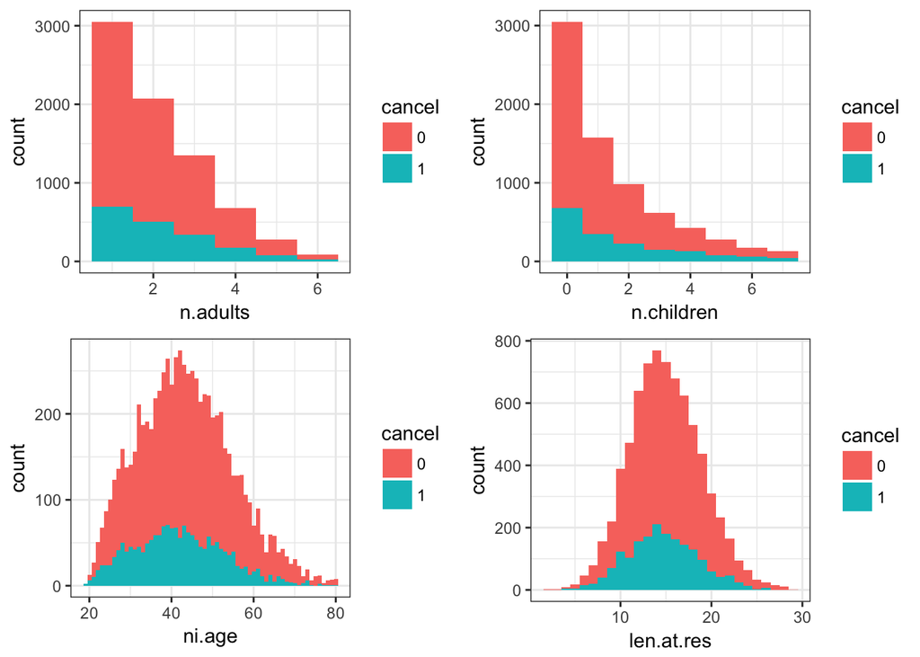

```r
full2$len.at.res[full2$len.at.res > len.at.resupper] <- NA

#see outcome, should be better than first hist
plots_muti(data = full2, fun = plot_hist, col_names_vector = c("n.adults", "n.children", "ni.age", "len.at.res"), ncol = 2)
```

## Correlation

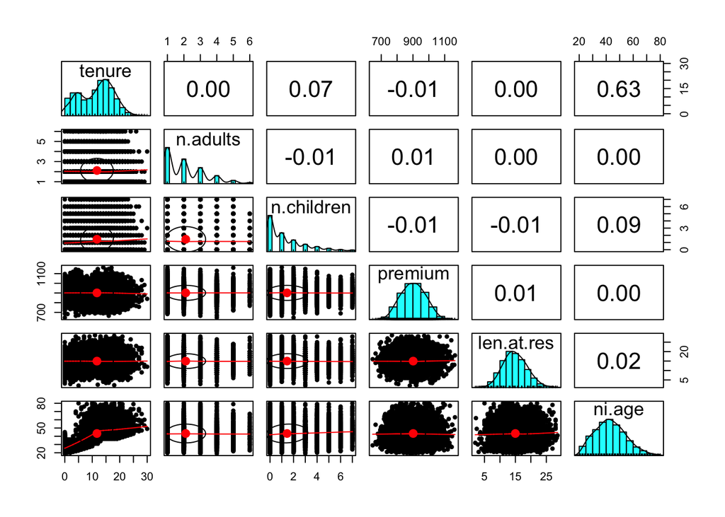

```r
pairs.panels(full2[numericname[c(-7, -8)]])
```

As we can see, almost all variables do not exist collinearity

# Data Cleaning & Shaping

## Data Imputation

```r
#check the number of NA
sapply(full2, function(x) sum(is.na(x)))
```

```
##            tenure         claim.ind          n.adults        n.children
##                 2                10                34               313
##         ni.gender ni.marital.status           premium     sales.channel
##                12                 7                 6                12
##     coverage.type     dwelling.type        len.at.res            credit
##                 4                11                75                11
##       house.color            ni.age              year          zip.code
##                 8                44                 0                 4
##            cancel
##                 0
```

```r
imputation <- mice(full2, m=1, maxit = 50, method = 'cart', printFlag = F, seed = 500)
fullmice <- complete(imputation)

#check the number of NA
sapply(fullmice, function(x) sum(is.na(x)))
```

```
##            tenure         claim.ind          n.adults        n.children
##                 0                 0                 0                 0
##         ni.gender ni.marital.status           premium     sales.channel
##                 0                 0                 0                 0
##     coverage.type     dwelling.type        len.at.res            credit
##                 0                 0                 0                 0
##       house.color            ni.age              year          zip.code
##                 0                 0                 0                 0
##            cancel
##                 0
```

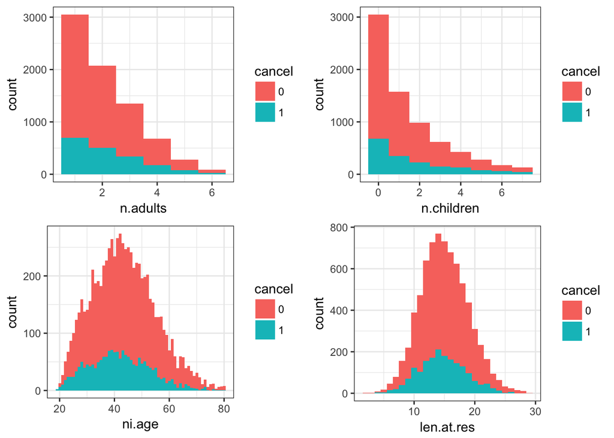

```r
#compare outcome since the number of NAs of the other variable are small
plots_muti(data = full2, fun = plot_hist, col_names_vector = c("n.adults", "n.children", "ni.age", "len.at.res"), ncol = 2)
```

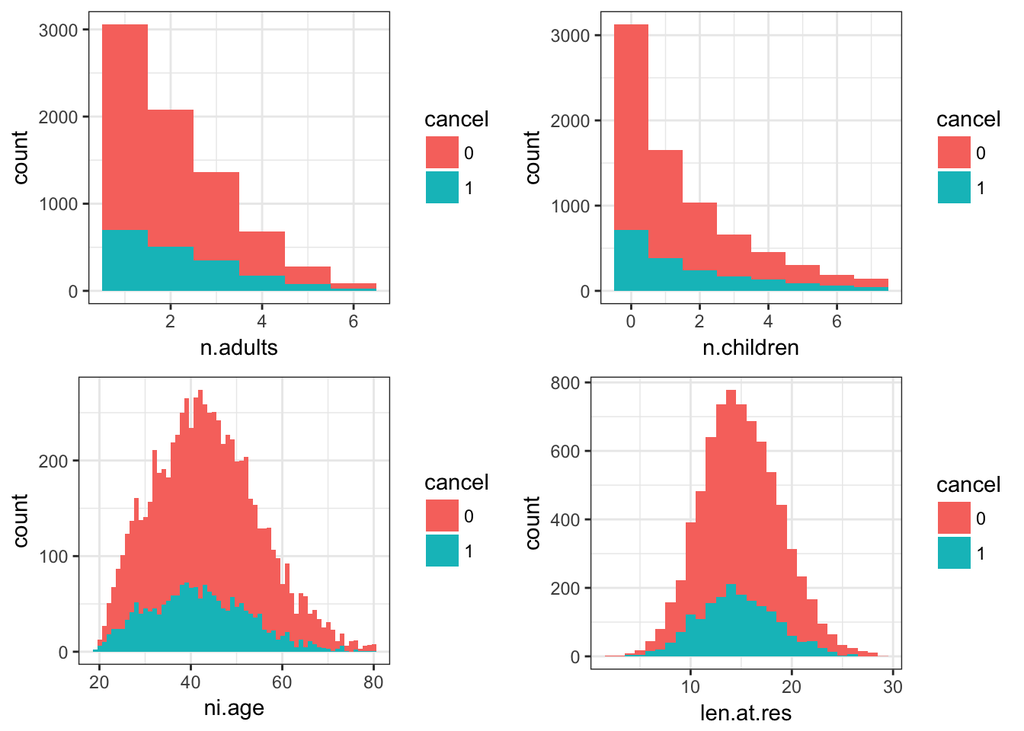

```r
plots_muti(data = fullmice, fun = plot_hist, col_names_vector = c("n.adults", "n.children", "ni.age", "len.at.res"), ncol = 2)
```

From above, I think the imputation is good since these variables’ distribution almost do not change.

## Feature Engineering

### New Derived Features

Since the Correlation coefficient between the n.adults and n.children is almost equal to zero, so I decide to generate the children proportion.

```r
#children proportion
fullmice$cp <- fullmice$n.children / (fullmice$n.children + fullmice$n.adults)
```

Also, I convet the zipcode to state.

```r
colnames(fullmice)[which(colnames(fullmice) == "zip.code")] <- "zip"
data("zipcode")
new <- merge(fullmice,zipcode,by='zip')
new$state <- as.factor(new$state)
newfull <- select(new, -zip, -city, -latitude, -longitude)
```

### Kmeans

Then, I would like to use Kmeans instead of PCA, since the Kmeans performance is better than PCA. Since this dataset has many of categorical variable. Using all the features makes the similarity between the observations too high and the clustering effect is not good. I firstly use RandomForest to filter the features and extract the overall importance 95% of the importance of variables for clustering.

```r
h2o.init(nthreads = -1)
```

[output not shown]

```r
rf_train <- as.h2o(newfull %>% filter(year != 2016))
rf_x <- names(newfull)[-c(14, 15)]
rf_y <- "cancel"

rf <- h2o.randomForest(x = rf_x,
                       y = rf_y,
                       model_id = "rf_features",
                       training_frame = rf_train,
                       ntrees = 300,
                       seed = 1)
rf_importance <- as.data.frame(rf@model$variable_importances)
which(cumsum(rf_importance$percentage) > 0.95)[1]
```

```
## [1] 13
```

```r
important_features <- rf_importance$variable[1:which(cumsum(rf_importance$percentage) > 0.95)[1]]
important_features
```

```
##  [1] "premium"       "tenure"        "len.at.res"    "state"
##  [5] "credit"        "house.color"   "cp"            "n.adults"
##  [9] "sales.channel" "n.children"    "coverage.type" "dwelling.type"
## [13] "ni.gender"
```

```r
km_train <- as.h2o(newfull)
km <- h2o.kmeans(x = important_features,
                 training_frame = rf_train,
                 model_id = "kmeans",
                 max_iterations = 1000,
                 k = 6,
                 seed = 1)
newfull$km <- as.factor(as.data.frame(predict(km, km_train))[, 1])
```

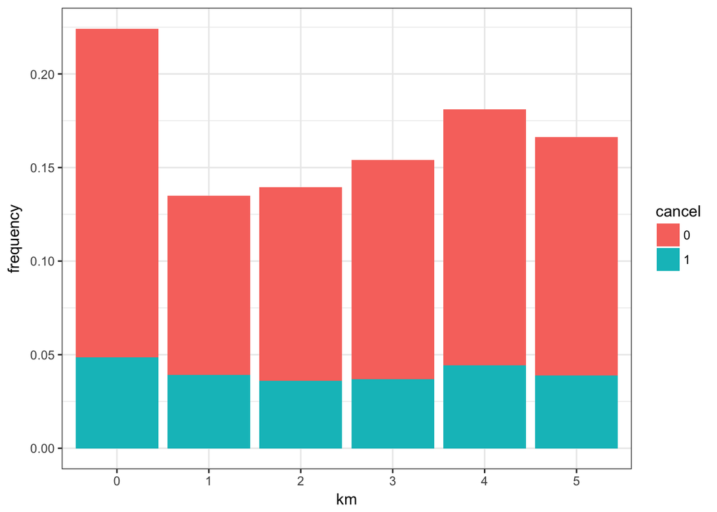

```r
#see performance
plot_freq(newfull, "km")
```

From above, I think the 6 clusters are pretty good, for dummy code, since package which I choose can convert to dummy variable automatically, so I do not do this things.

## Normalization/Standardization of feature values

```r
normalfull <- newfull
normalize <- function(x) {
  return ((x - min(x)) / (max(x) - min(x)))
}

normalname <- colnames(normalfull[, sapply(normalfull, function(x) is.numeric(x))])
normalfull[,normalname[-7]] <- sapply(newfull[,normalname[-7]], normalize)
```

# Model Construction & Evaluation

## Creation of Training & Validation Subset

```r
#sepearte train and test, for the year, I think we do not need, since we use the past to predict furture, the year is useless and in training data, the year of 2016 did not have. This is also a mistake when we consturted model.
train <- normalfull %>% filter(year != 2016) %>% select(-year)
test <- normalfull %>% filter(year == 2016) %>% select(-year)
```

## Construction Model

### Support Vector Machine

The first maching learning algorithm is Support Vector Machine since this dataset has so many categorical variables, so, I think the Support Vector Machine is suitable and the performance should be better.

```r
#convert to dummy variable first
svm_train <- as.data.frame(model.matrix(~.,train))[-1]
svm_test <- as.data.frame(model.matrix(~.,test))[-1]

#generate level
svm_train$cancel2 <- as.factor(svm_train$cancel2)
svm_test$cancel2 <- as.factor(svm_test$cancel2)
levels(svm_train$cancel2) <- make.names(levels(svm_train$cancel2))
levels(svm_test$cancel2) <- make.names(levels(svm_test$cancel))

set.seed(1492)
#5-folds cross validation
ctrl <- trainControl(method = "cv",
                     n = 5,
                     summaryFunction = twoClassSummary,
                     classProbs = TRUE)
svm.grid <- expand.grid(sigma = seq(0.1, 0.5, 0.1),
                        C = seq(0.5, 1.5, 0.2))
svm <- train(cancel2 ~ .,
             svm_train,
             method = "svmRadial",
             metric = "ROC",
             preProc = c("center","scale"),
             trControl = ctrl,
             tuneGrid = svm.grid)
svm$bestTune
```

```
##    sigma   C
## 25   0.5 0.5
```

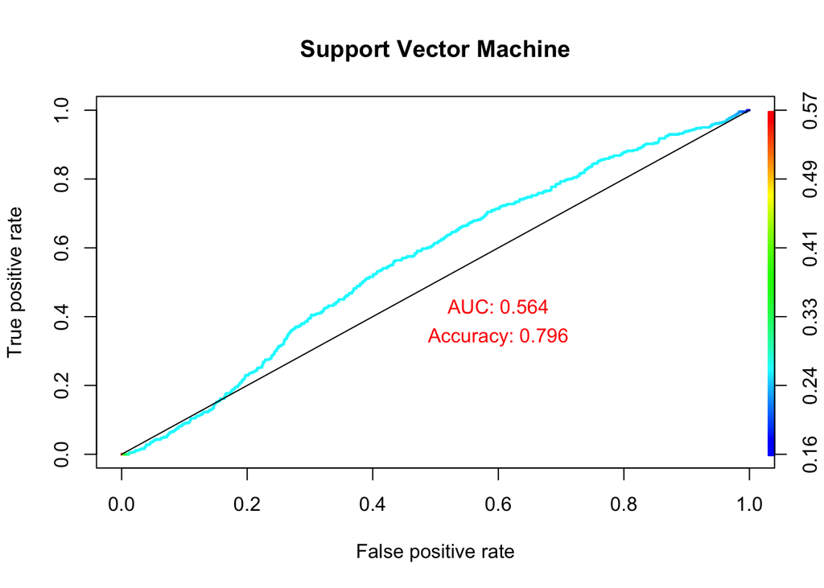

```r
svm_prob <- predict(svm, svm_test, type = "prob")
svm_input <- prediction(svm_prob[,2], svm_test$cancel2)

svm_auc <- performance(svm_input,"auc")@y.values
svm_accuracy <- mean(predict(svm, svm_test) == svm_test$cancel2)

#plot the ROC curve
svm_perf = performance(svm_input, "tpr", "fpr")
plot(svm_perf, lwd=2, colorize=TRUE, main = "Support Vector Machine")
lines(x=c(0, 1), y=c(0, 1), col="black", lwd=1)
text(0.6, 0.43, labels=sprintf("AUC: %0.3f", svm_auc), col="red")
text(0.6, 0.34, labels=sprintf("Accuracy: %0.3f", svm_accuracy), col="red")
```

For the SVM, this outcome is a little bad, so I decide use some boosting or tree algorithm.

### Gradient Boosting Machine

```r
x <- names(train)[-15]
y <- "cancel"
#cross validation
nfolds <- 5
fold_assignment <- "Modulo"

#splits data into training and validation
splits <- h2o.splitFrame(
  data = as.h2o(train),
  ratios = 0.7,
  seed = 1234)
training <- splits[[1]]
validation <- splits[[2]]
testing <- as.h2o(test)
```

```r
search_criteria = list(
  strategy = "RandomDiscrete",
  max_runtime_secs = 3600,
  max_models = 100,
  seed = 1234,
  stopping_rounds = 5,
  stopping_metric = "AUC",
  stopping_tolerance = 1e-4)

hyper_params = list(
  max_depth = seq(1,10,1),
  sample_rate = seq(0.2,1,0.02),
  col_sample_rate = seq(0.2,1,0.02),
  col_sample_rate_per_tree = seq(0.2,1,0.02),
  col_sample_rate_change_per_level = seq(0.9,1.1,0.02),
  min_rows = 2^seq(0,log2(nrow(training))-1,1),
  nbins = 2^seq(4,10,1),
  nbins_cats = 2^seq(4,12,1),
  min_split_improvement = c(0,1e-8,1e-6,1e-4),
  histogram_type = c("UniformAdaptive","QuantilesGlobal","RoundRobin"),
  learn_rate = seq(0.001,0.07,0.003),
  learn_rate_annealing = seq(0.8,0.99,0.02))

grid <- h2o.grid(
  hyper_params = hyper_params,
  search_criteria = search_criteria,
  algorithm = "gbm",
  grid_id = "gbm_grid",
  x = x,
  y = y,
  training_frame = training,
  validation_frame = validation,
  ntrees = 10000,
  distribution = "bernoulli",
  #dummy code
  categorical_encoding = "AUTO",
  nfolds = nfolds,
  fold_assignment = fold_assignment,
  keep_cross_validation_predictions = TRUE,
  score_tree_interval = 10,
  seed = 1234)
gbm_grid <- h2o.getGrid("gbm_grid", sort_by = "auc", decreasing = T)
gbm_grid
```

```
## H2O Grid Details
## ================
##
## Grid ID: gbm_grid
## Used hyper parameters:
##   -  col_sample_rate
##   -  col_sample_rate_change_per_level
##   -  col_sample_rate_per_tree
##   -  histogram_type
##   -  learn_rate
##   -  learn_rate_annealing
##   -  max_depth
##   -  min_rows
##   -  min_split_improvement
##   -  nbins
##   -  nbins_cats
##   -  sample_rate
## Number of models: 100
## Number of failed models: 0
##
## Hyper-Parameter Search Summary: ordered by decreasing auc
##   col_sample_rate col_sample_rate_change_per_level
## 1            0.22                             1.02
## 2            0.52                              0.9
## 3            0.54                             1.06
## 4            0.34                             1.04
## 5            0.74                              1.0
##   col_sample_rate_per_tree  histogram_type learn_rate learn_rate_annealing
## 1                     0.94 QuantilesGlobal      0.058                 0.98
## 2                     0.56      RoundRobin      0.046                 0.98
## 3                     0.42      RoundRobin      0.067                 0.96
## 4                     0.98 QuantilesGlobal       0.04                 0.96
## 5                      0.6 QuantilesGlobal      0.061                 0.96
##   max_depth min_rows min_split_improvement nbins nbins_cats sample_rate
## 1         9    256.0                1.0E-8   256        128         0.7
## 2         5      1.0                1.0E-8    16         64         1.0
## 3        10    128.0                1.0E-8  1024       2048        0.72
## 4         3     16.0                   0.0    32        512        0.68
## 5         8    128.0                1.0E-4  1024        512        0.22
##           model_ids                auc
```

[output cut: 20 more lines]

```
## 100                     0.28 UniformAdaptive      0.004
##     learn_rate_annealing max_depth min_rows min_split_improvement nbins
## 95                  0.94         7      8.0                1.0E-6    64
## 96                  0.84         1      4.0                1.0E-6  1024
## 97                   0.9         6      8.0                1.0E-8    64
## 98                  0.86         2      2.0                1.0E-8   512
## 99                  0.82        10    256.0                1.0E-4    32
## 100                 0.84         5      4.0                1.0E-6  1024
##     nbins_cats sample_rate         model_ids                auc
## 95        4096        0.22 gbm_grid_model_20  0.616014283836544
## 96          32        0.58  gbm_grid_model_5 0.6122432729904193
## 97          64        0.54 gbm_grid_model_51 0.6105881520277444
## 98          64        0.56 gbm_grid_model_99 0.6058872979441617
## 99          64        0.36 gbm_grid_model_28 0.5953120012248654
## 100        512        0.78 gbm_grid_model_71 0.5507196083897499
```

```r
gbm <- h2o.getModel(gbm_grid@model_ids[[1]])

h2o.varimp(gbm)
```

```
## Variable Importances:
##             variable relative_importance scaled_importance percentage
## 1             credit         1181.495239          1.000000   0.327156
## 2              state          595.657410          0.504156   0.164937
## 3      sales.channel          487.213135          0.412370   0.134909
## 4             ni.age          259.237640          0.219415   0.071783
## 5             tenure          159.979767          0.135404   0.044298
## 6            premium          134.283432          0.113655   0.037183
## 7                 km          125.240974          0.106002   0.034679
## 8           n.adults          112.014496          0.094807   0.031017
## 9         n.children          111.853828          0.094671   0.030972
## 10        len.at.res          109.148468          0.092382   0.030223
## 11                cp           87.892067          0.074391   0.024337
## 12         claim.ind           81.808342          0.069241   0.022653
## 13       house.color           43.715160          0.037000   0.012105
## 14 ni.marital.status           42.451496          0.035930   0.011755
## 15     coverage.type           31.865021          0.026970   0.008823
## 16     dwelling.type           28.376442          0.024017   0.007857
## 17         ni.gender           19.181162          0.016235   0.005311
```

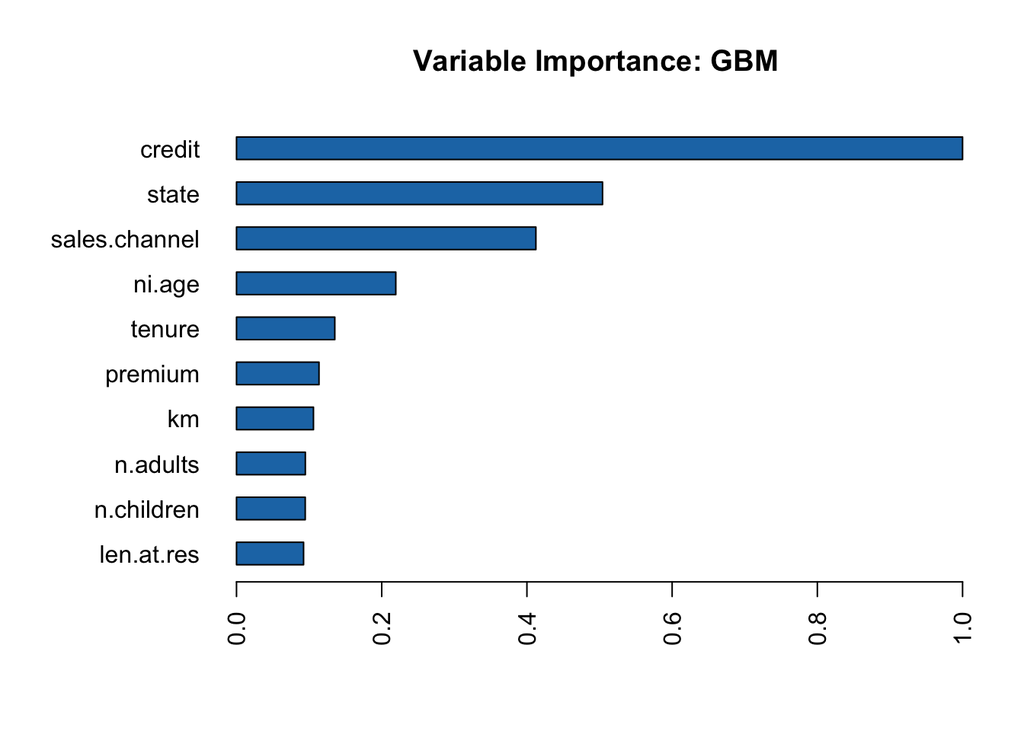

```r
h2o.varimp_plot(gbm)
```

```r
gbm_pred <- h2o.predict(gbm, testing)
```

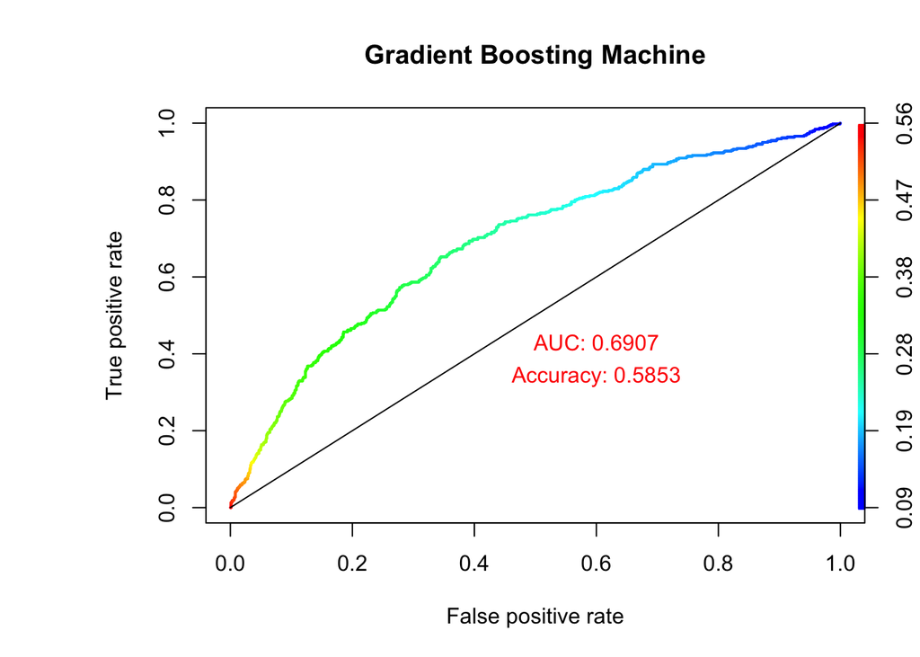

```r
gbm_accuracy <- mean(gbm_pred$predict == testing$cancel)
gbm_auc <- h2o.auc(h2o.performance(gbm, testing))

gbm_input <- prediction(as.vector(gbm_pred$p1), test$cancel)
gbm_perf = performance(gbm_input, "tpr", "fpr")
plot(gbm_perf, lwd=2, colorize=TRUE, main = "Gradient Boosting Machine")
lines(x=c(0, 1), y=c(0, 1), col="black", lwd=1)
text(0.6, 0.43, labels=sprintf("AUC: %0.4f", gbm_auc), col="red")
text(0.6, 0.34, labels=sprintf("Accuracy: %0.4f", gbm_accuracy), col="red")
```

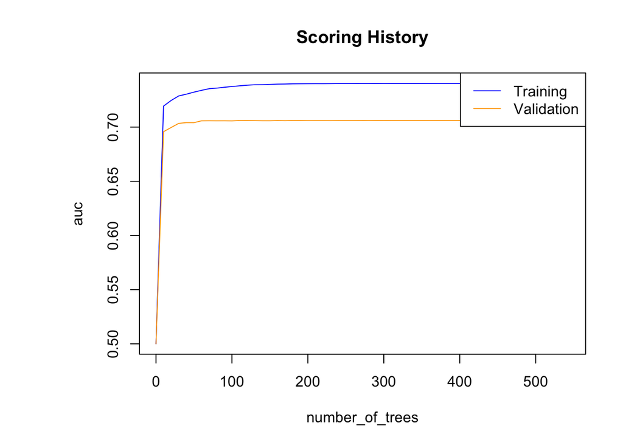

```r
plot(gbm, metric = "auc")
```

### Deep Learining

```r
hyper_params <- list(
  hidden = list(c(25,25), c(30, 30, 30), c(5, 5, 5, 5)),
  epochs = c(50, 100, 200),
  l1 = seq(0,1e-3,1e-6),
  l2 = seq(0,1e-3,1e-6),
  rho = c(0.9, 0.95, 0.99),
  epsilon = c(1e-10, 1e-8, 1e-6, 1e-4),
  input_dropout_ratio = c(0, 0.05, 0.1, 0.2),
  max_w2=c(10, 100),
  activation=c("Rectifier",
               "Tanh",
               "Maxout",
               "RectifierWithDropout",
               "MaxoutWithDropout")
)

dl_random_grid <- h2o.grid(
  algorithm="deeplearning",
  grid_id = "dl_grid",
  training_frame = training,
  validation_frame = validation,
  x=x,
  y=y,
  score_validation_samples=10000,
  score_duty_cycle=0.025,
  distribution = "bernoulli",
  hyper_params = hyper_params,
  nfolds = nfolds,
  fold_assignment = fold_assignment,
  keep_cross_validation_predictions = TRUE,
  search_criteria = search_criteria,
  categorical_encoding = "AUTO",
  seed = 1234)
dl_grid <- h2o.getGrid("dl_grid",sort_by="auc",decreasing=T)
dl_grid
```

```
## H2O Grid Details
## ================
##
## Grid ID: dl_grid
## Used hyper parameters:
##   -  activation
##   -  epochs
##   -  epsilon
##   -  hidden
##   -  input_dropout_ratio
##   -  l1
##   -  l2
##   -  max_w2
##   -  rho
## Number of models: 100
## Number of failed models: 0
##
## Hyper-Parameter Search Summary: ordered by decreasing auc
##             activation epochs epsilon   hidden input_dropout_ratio      l1
## 1    MaxoutWithDropout  200.0 1.0E-10 [25, 25]                0.05 4.72E-4
## 2    MaxoutWithDropout   52.0  1.0E-8 [25, 25]                 0.1  6.1E-5
## 3 RectifierWithDropout   52.0  1.0E-8 [25, 25]                 0.1 4.95E-4
## 4                 Tanh   52.0 1.0E-10 [25, 25]                 0.1 8.65E-4
## 5 RectifierWithDropout  104.0  1.0E-8 [25, 25]                 0.1 1.79E-4
##        l2 max_w2  rho        model_ids                auc
## 1 6.64E-4   10.0 0.99 dl_grid_model_75 0.7179572409330354
## 2  5.0E-4   10.0 0.99 dl_grid_model_97 0.7170171062267359
## 3  8.9E-4   10.0 0.95 dl_grid_model_38 0.7154504557856832
## 4 9.42E-4   10.0 0.99 dl_grid_model_98 0.7141318839093427
## 5  2.9E-5   10.0 0.95 dl_grid_model_87 0.7129348235861689
##
## ---
##               activation epochs epsilon       hidden input_dropout_ratio
## 95  RectifierWithDropout   52.0  1.0E-4 [5, 5, 5, 5]                 0.0
## 96                  Tanh  200.0  1.0E-4 [5, 5, 5, 5]                 0.1
## 97     MaxoutWithDropout  104.0  1.0E-4 [5, 5, 5, 5]                 0.2
## 98                  Tanh  200.0  1.0E-4 [5, 5, 5, 5]                 0.2
## 99                Maxout   52.0  1.0E-4 [5, 5, 5, 5]                 0.1
## 100               Maxout   52.0  1.0E-4 [5, 5, 5, 5]                0.05
##          l1      l2 max_w2  rho        model_ids                 auc
## 95  8.91E-4 7.06E-4  100.0  0.9 dl_grid_model_19  0.5064262098073004
## 96  1.14E-4 3.05E-4  100.0 0.99 dl_grid_model_33  0.5046409107913814
## 97  2.31E-4 8.18E-4   10.0 0.99 dl_grid_model_59  0.5045632733948558
## 98  4.65E-4 9.84E-4   10.0 0.99 dl_grid_model_85                 0.5
## 99  7.36E-4  7.1E-4   10.0 0.99 dl_grid_model_82   0.495905078713487
## 100 6.99E-4 6.29E-4   10.0 0.99 dl_grid_model_95 0.49535908920861854
```

```r
dl <- h2o.getModel(dl_grid@model_ids[[1]])

h2o.varimp(dl)
```

```
## Variable Importances:
##              variable relative_importance scaled_importance percentage
## 1                km.1            1.000000          1.000000   0.048660
## 2             premium            0.912095          0.912095   0.044383
## 3 ni.marital.status.0            0.826918          0.826918   0.040238
## 4 ni.marital.status.1            0.763999          0.763999   0.037176
## 5         claim.ind.0            0.688034          0.688034   0.033480
##
## ---
##                         variable relative_importance scaled_importance
## 46     sales.channel.missing(NA)            0.000000          0.000000
## 47     coverage.type.missing(NA)            0.000000          0.000000
## 48     dwelling.type.missing(NA)            0.000000          0.000000
## 49         ni.gender.missing(NA)            0.000000          0.000000
## 50 ni.marital.status.missing(NA)            0.000000          0.000000
## 51         claim.ind.missing(NA)            0.000000          0.000000
##    percentage
## 46   0.000000
## 47   0.000000
## 48   0.000000
## 49   0.000000
## 50   0.000000
## 51   0.000000
```

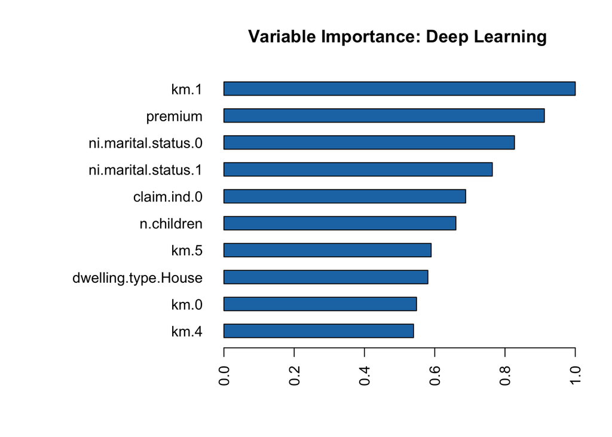

```r
h2o.varimp_plot(dl)
```

```r
dl_pred <- h2o.predict(dl, testing)
```

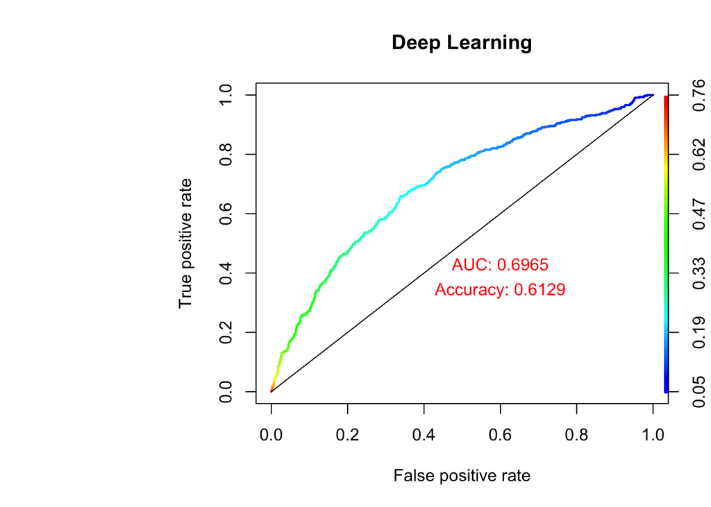

```r
dl_accuracy <- mean(dl_pred$predict == testing$cancel)
dl_auc <- h2o.auc(h2o.performance(dl, testing))

dl_input <- prediction(as.vector(dl_pred$p1), test$cancel)
dl_perf = performance(dl_input, "tpr", "fpr")
plot(dl_perf, lwd=2, colorize=TRUE, main = "Deep Learning")
lines(x=c(0, 1), y=c(0, 1), col="black", lwd=1)
text(0.6, 0.43, labels=sprintf("AUC: %0.4f", dl_auc), col="red")
text(0.6, 0.34, labels=sprintf("Accuracy: %0.4f", dl_accuracy), col="red")
```

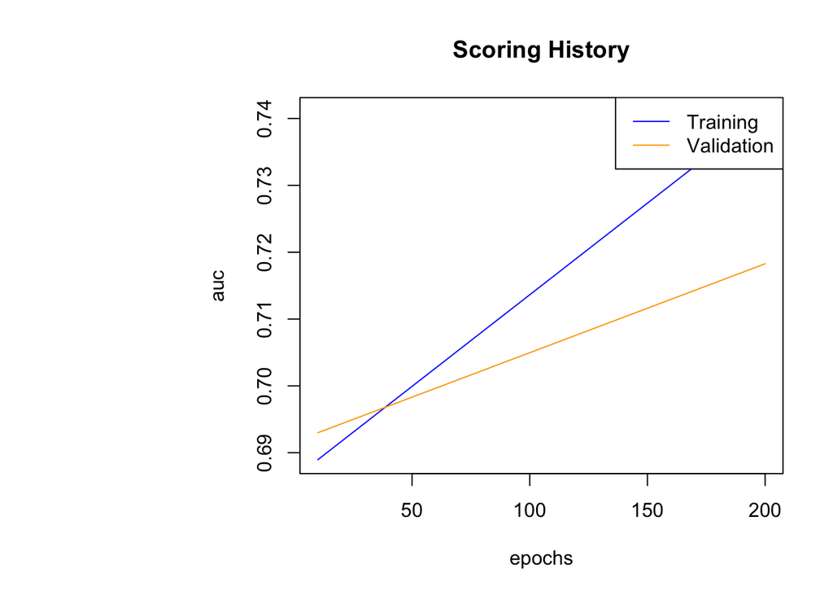

```r
plot(dl, metric = "auc")
```

## Constructino of Stacked Ensemble Model

```r
base_models <- list(dl_grid@model_ids[[1]],
                    dl_grid@model_ids[[2]],
                    dl_grid@model_ids[[3]])

ensemble <- h2o.stackedEnsemble(x = x,
                    y = y,
                    training_frame = training,
                    validation_frame = validation,
                    base_models = base_models)
ensemble_pred <- h2o.predict(ensemble, testing)
```

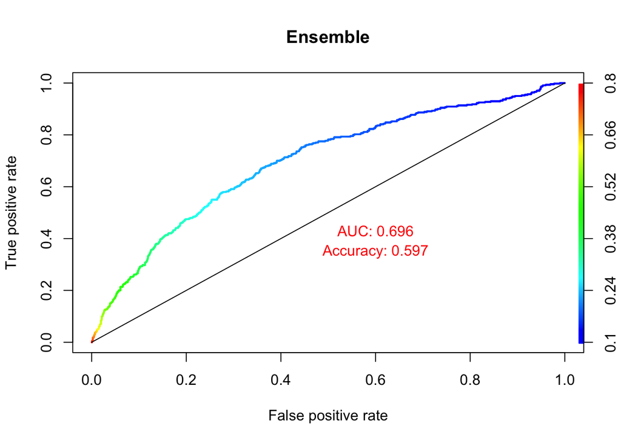

```r
ensemble_accuracy <- mean(ensemble_pred$predict == testing$cancel)
ensemble_auc <- h2o.auc(h2o.performance(ensemble, testing))

ensemble_input <- prediction(as.vector(ensemble_pred$p1), test$cancel)
ensemble_perf = performance(ensemble_input, "tpr", "fpr")
plot(ensemble_perf, lwd=2, colorize=TRUE, main = "Ensemble")
lines(x=c(0, 1), y=c(0, 1), col="black", lwd=1)
text(0.6, 0.43, labels=sprintf("AUC: %0.3f", ensemble_auc), col="red")
text(0.6, 0.35, labels=sprintf("Accuracy: %0.3f", ensemble_accuracy), col="red")
```

## Comparision of Models

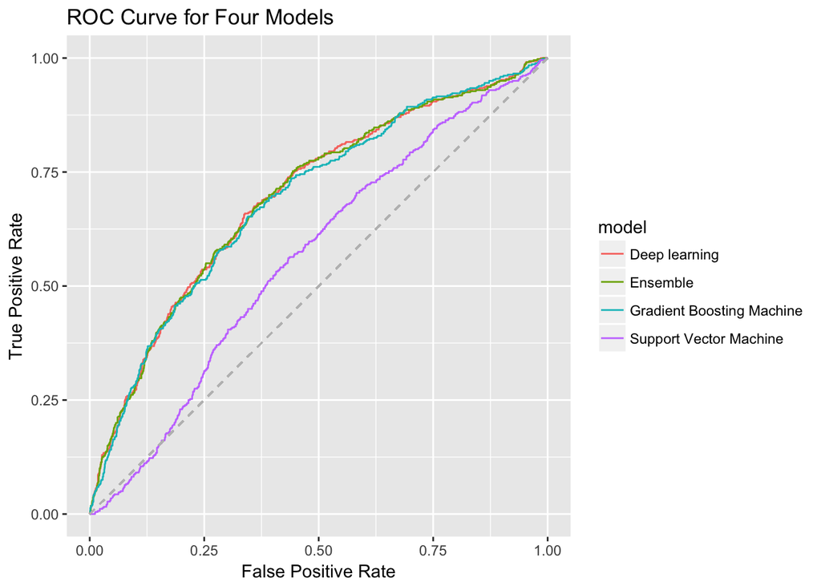

```r
svm_fpr <- svm_perf@x.values[[1]]
svm_tpr <- svm_perf@y.values[[1]]

gbm_fpr <- gbm_perf@x.values[[1]]
gbm_tpr <- gbm_perf@y.values[[1]]

dl_fpr <- dl_perf@x.values[[1]]
dl_tpr <- dl_perf@y.values[[1]]

ensemble_fpr <- ensemble_perf@x.values[[1]]
ensemble_tpr <- ensemble_perf@y.values[[1]]

compare_roc <- data.frame(tpr=c(svm_tpr, gbm_tpr, dl_tpr, ensemble_tpr),
                      fpr=c(svm_fpr, gbm_fpr, dl_fpr, ensemble_fpr),
                      model=c(rep("Support Vector Machine", each = length(svm_tpr)),
                               rep("Gradient Boosting Machine", each = length(gbm_tpr)),
                               rep("Deep learning", each = length(dl_tpr)),
                               rep("Ensemble", each = length(ensemble_tpr))))
ggplot(aes(fpr, tpr, color = model), data = compare_roc) +
  geom_line() +
  geom_segment(aes(x = 0, y = 0 , xend = 1, yend = 1), linetype = 2,col='grey') +
  xlab('False Positive Rate') +
  ylab('True Positive Rate') +
  ggtitle('ROC Curve for Four Models')
```

```r
print(sprintf("Support Vector Machine AUC: %0.3f", svm_auc))
```

```
## [1] "Support Vector Machine AUC: 0.564"
```

```r
print(sprintf("Gradient Boosting Machine AUC: %0.3f", gbm_auc))
```

```
## [1] "Gradient Boosting Machine AUC: 0.691"
```

```r
print(sprintf("Deep learning AUC: %0.3f", dl_auc))
```

```
## [1] "Deep learning AUC: 0.697"
```

```r
print(sprintf("Ensemble AUC: %0.3f", ensemble_auc))
```

```
## [1] "Ensemble AUC: 0.696"
```

```r
print(sprintf("Deep learning Accuracy: %0.3f", dl_accuracy))
```

```
## [1] "Deep learning Accuracy: 0.613"
```